# ST 558 Project 2

Matthew Sookoo and Rachel Hardy

2022-10-10

# Introduction

Our goal with this project is to create a vignette about contacting an API using functions we’ve created to query, parse, and return well-structured data. We’ll then use our functions to obtain data from the API and do some exploratory data analysis!

# Required packages

To use the functions for interacting with the API, the following packages are used:

- `tidyverse`: Tons of useful features for data manipulation and visualization!
- `jsonlite`: Used for API interaction.
- `httr`: Used to make http requests in R language as it provides a wrapper for the curl package.
- `knitr`: Used for displaying tables in a markdown-friendly way.

# Writing the Functions

In this section we will write the functions for data retrieval. These functions will allow the user to customize their query to return specific data. We will be using an API that is focused on breweries. Each function will return a data frame with variables such as brewery ID, name, type, address (street, city, and state variables), postal code, country, longitude, latitude, phone number, and website URL to name a few. Each function will have a brief description.

## Function Number One: listBreweries()

The first function is a function that will return a list of breweries of user-specified length. Default length is 20 and maximum length is 50.

```r
listBreweries <- function(length = 20) {

  #Create the full URL that will be used to retrieve the data.
  baseURL <- "https://api.openbrewerydb.org/"
  endpoint <- "breweries?per_page="
  fullURL = paste0(baseURL, endpoint, length)

  #Get the API output.
  outputAPI <- GET(fullURL)

  #Parse the API output to get a data frame.
  finalAPI <- fromJSON(rawToChar(outputAPI$content))

  #Return the final data frame.
  return(as_tibble(finalAPI))
}
```

## Function Number Two: listByState()

The second function is a function that will return a list of breweries of user-specified length and state. Default length is 20 and default state is North Carolina.

```r
listByState <- function(state = "North Carolina", length = 20) {

  #Make sure state is all lowercase with underscores instead of spaces.
  state <- tolower(state)
  state <- sub(" ", "_", state)

  #Create the full URL that will be used to retrieve the data.
  baseURL <- "https://api.openbrewerydb.org/"
  endpoint1 <- "breweries?by_state="
  endpoint2 <- "&per_page="
  fullURL = paste0(baseURL, endpoint1, state, endpoint2, length)

  #Get the API output.
  outputAPI <- GET(fullURL)

  #Parse the API output to get a data frame.
  finalAPI <- fromJSON(rawToChar(outputAPI$content))

  #Return the final data frame.
  return(as_tibble(finalAPI))
}
```

## Function Number Three: listByCity()

The third function is a function that will return a list of breweries of user-specified length and city. Default length is 20 and default city is San Diego, California.

```r
listByCity <- function(city = "San Diego", length = 20) {

  #Make sure city is all lowercase with underscores instead of spaces.
  city <- tolower(city)
  city <- sub(" ", "_", city)

  #Create the full URL that will be used to retrieve the data.
  baseURL <- "https://api.openbrewerydb.org/"
  endpoint1 <- "breweries?by_city="
  endpoint2 <- "&per_page="
  fullURL = paste0(baseURL, endpoint1, city, endpoint2, length)

  #Get the API output.
  outputAPI <- GET(fullURL)

  #Parse the API output to get a data frame.
  finalAPI <- fromJSON(rawToChar(outputAPI$content))

  #Return the final data frame.
  return(as_tibble(finalAPI))
}
```

## Function Number Four: listByDistance()

The fourth function is a function that will return a list of breweries of user-specified length and sort the results by distance from a user-specified origin point (latitude, longitude). Default length is 20 and default origin point is Raleigh, North Carolina (35.7796, -78.6382).

```r
listByDistance <- function(lat = 35.7796, long = -78.6382, length = 20) {

  #Create the full URL that will be used to retrieve the data.
  baseURL <- "https://api.openbrewerydb.org/"
  endpoint1 <- "breweries?by_dist="
  endpoint2 <- "&per_page="
  fullURL = paste0(baseURL, endpoint1, lat, ",", long, endpoint2, length)

  #Get the API output.
  outputAPI <- GET(fullURL)

  #Parse the API output to get a data frame.
  finalAPI <- fromJSON(rawToChar(outputAPI$content))

  #Return the final data frame.
  return(as_tibble(finalAPI))
}
```

## Function Number Five: listByType()

The fifth function is a function that will return a list of breweries of user-specified length and type. Default length is 20 and default type is micro.

The different types of breweries are listed below:

- `micro`: Most craft breweries. For example, Samuel Adams is still considered a micro brewery.
- `nano`: An extremely small brewery which typically only distributes locally.
- `regional`: A regional location of an expanded brewery. Ex. Sierra Nevada’s Asheville, NC location.
- `brewpub`: A beer-focused restaurant or restaurant/bar with a brewery on-premise.
- `large`: A very large brewery. Likely not for visitors. Ex. Miller-Coors. (deprecated)
- `planning`: A brewery in planning or not yet opened to the public.
- `bar`: A bar. No brewery equipment on premise. (deprecated)
- `contract`: A brewery that uses another brewery’s equipment.
- `proprietor`: Similar to contract brewing but refers more to a brewery incubator.
- `closed`: A location which has been closed.

```r
listByType <- function(type = "micro", length = 20) {

  #Make sure type is all lowercase.
  type <- tolower(type)

  #Create the full URL that will be used to retrieve the data.
  baseURL <- "https://api.openbrewerydb.org/"
  endpoint1 <- "breweries?by_type="
  endpoint2 <- "&per_page="
  fullURL = paste0(baseURL, endpoint1, type, endpoint2, length)

  #Get the API output.
  outputAPI <- GET(fullURL)

  #Parse the API output to get a data frame.
  finalAPI <- fromJSON(rawToChar(outputAPI$content))

  #Return the final data frame.
  return(as_tibble(finalAPI))
}
```

## Function Number Six: listBySearch()

The sixth function is a function that will return a list of breweries of user-specified length based on a search term. Default length is 20 and the user *must* specify a search term.

```r
listBySearch <- function(search, length = 20) {

  #Make sure the search term is all lowercase with underscores instead of spaces.
  search <- tolower(search)
  search <- sub(" ", "_", search)

  #Create the full URL that will be used to retrieve the data.
  baseURL <- "https://api.openbrewerydb.org/"
  endpoint1 <- "breweries/search?query="
  endpoint2 <- "&per_page="
  fullURL = paste0(baseURL, endpoint1, search, endpoint2, length)

  #Get the API output.
  outputAPI <- GET(fullURL)

  #Parse the API output to get a data frame.
  finalAPI <- fromJSON(rawToChar(outputAPI$content))

  #Return the final data frame.
  return(as_tibble(finalAPI))
}
```

# Data Retreival and Exploratory Analysis

In this section we will use the functions from the previous section to extract our data and then we will analyze it using the `tidyverse` package!

Some requirements for this section are listed below:

- You should pull data from at least two calls to your obtaining data function (possibly combining them into one).
- You should create at least one new variable that is a function of other variables.
- You should create some contingency tables.
- You should create numerical summaries for some quantitative variables at each setting of some of your categorical variables.
- You should create at least five plots utilizing coloring, grouping, etc. All plots should have nice labels and titles.
  - You should have at least one bar plot, one histogram, one box plot, and one scatter plot.

We maybe interested in the percentage of brewpub (A beer-focused restaurant or restaurant/bar with a brewery on-premise) or bar (A bar. No brewery equipment on premise) breweries in Wisconsin and North Dakota as these two states were found to be the two states that consumed the most alcohol. click [Here](https://www.thecentersquare.com/wisconsin/this-is-where-wisconsin-ranks-among-the-drunkest-states-in-america/article_3ccd11a4-c261-563b-919a-e02a0254b6dd.html) for more information.

```r
wisconsin <- listByState("Wisconsin", 50)
ndakota <- listByState("North Dakota", 50)
combined_tibble <- rbind(wisconsin, ndakota)%>%
# we create a new helper variable "brewpub_or_bar_1_0" to display 1 if brewery type is either "brewpub or "bar". We delete this variable later on
  mutate(brewpub_or_bar_1_0=if_else((brewery_type == "brewpub"|brewery_type == "bar"), 1, 0))%>%


  group_by(state)%>%

  mutate(percent_brewpub_bar = mean(brewpub_or_bar_1_0)*100) %>%

  # we delete the unwanted variable brewpub_or_bar_1_0

  select(-brewpub_or_bar_1_0)%>%

  select(percent_brewpub_bar,  everything())

combined_tibble
```

```
## # A tibble: 76 × 18
## # Groups:   state [2]
##    percent_brew…¹ id    name  brewe…² street addre…³ addre…⁴ city  state count…⁵
##             <dbl> <chr> <chr> <chr>   <chr>  <lgl>   <lgl>   <chr> <chr> <lgl>
##  1             38 1840… 1840… micro   342 E… NA      NA      Milw… Wisc… NA
##  2             38 3-sh… 3 Sh… micro   1837 … NA      NA      Sheb… Wisc… NA
##  3             38 608-… 608 … planni… <NA>   NA      NA      La C… Wisc… NA
##  4             38 841-… 841 … brewpub 841 E… NA      NA      Whit… Wisc… NA
##  5             38 8th-… 8th … brewpub 1132 … NA      NA      Sheb… Wisc… NA
##  6             38 agon… Agon… planni… <NA>   NA      NA      Rice… Wisc… NA
##  7             38 ahna… Ahna… micro   N9153… NA      NA      Algo… Wisc… NA
##  8             38 ale-… Ale … region… 2002 … NA      NA      Madi… Wisc… NA
##  9             38 alt-… ALT … brewpub 1808 … NA      NA      Madi… Wisc… NA
## 10             38 angr… Angr… brewpub 10440… NA      NA      Hayw… Wisc… NA
## # … with 66 more rows, 8 more variables: postal_code <chr>, country <chr>,
## #   longitude <chr>, latitude <chr>, phone <chr>, website_url <chr>,
## #   updated_at <chr>, created_at <chr>, and abbreviated variable names
## #   ¹percent_brewpub_bar, ²brewery_type, ³address_2, ⁴address_3,
## #   ⁵county_province
```

A “brewpub” according is defined as a beer-focused restaurant or restaurant/bar with a brewery on-premise and “bar” is defined as a bar with no brewery equipment on premise.

## contingency table

We are interested in the two states with the highest consumption of alcohol, namely Wisconsin and North Dakota. We show a contingency table for brewery type in Wisconsin, another contingency table for brewery type in North Dakota and finally a two-way contingency table for brewery_type for both states.

```r
wisconsin_only<-combined_tibble %>% filter(state == "Wisconsin")
table(wisconsin_only$brewery_type)
```

```
##
##  brewpub contract    micro planning regional
##       19        3       19        5        4
```

```r
n_dakota_only<-combined_tibble %>% filter(state == "North Dakota")
table(n_dakota_only$brewery_type)
```

```
##
##     bar brewpub  closed   micro    nano
##       1       8       3      12       2
```

```r
table(combined_tibble$brewery_type, combined_tibble$state)
```

```
##
##            North Dakota Wisconsin
##   bar                 1         0
##   brewpub             8        19
##   closed              3         0
##   contract            0         3
##   micro              12        19
##   nano                2         0
##   planning            0         5
##   regional            0         4
```

Next we create some numerical summaries for the mean and standard deviations of the longitude and latitude values across our two states of interest Wisconsin and North Dakota. It should be noted that the combine_tibble object is already group_by(state) and we remove the Na values.

```r
combined_tibble%>%filter(longitude != "Na", latitude != "Na")%>%
  mutate(longitude = as.numeric(longitude))%>%
  mutate(latitude = as.numeric(latitude))%>%
summarize(mean(longitude), mean(latitude), sd(longitude), sd(latitude))
```

```
## # A tibble: 2 × 5
##   state        `mean(longitude)` `mean(latitude)` `sd(longitude)` `sd(latitude)`
##   <chr>                    <dbl>            <dbl>           <dbl>          <dbl>
## 1 North Dakota             -99.3             47.2            2.39          0.554
## 2 Wisconsin                -89.1             43.7            1.33          0.853
```

## Plots

### Histogram

We can use a continuous valued variable such as latitude or longitude.

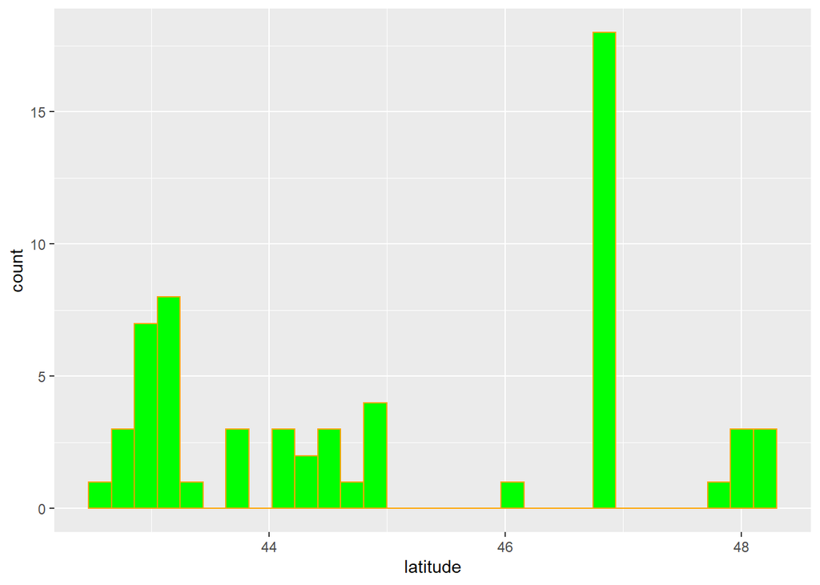

```r
combined_tibble2 <- combined_tibble%>%filter(longitude != "Na", latitude != "Na")%>%
  mutate(longitude = as.numeric(longitude))%>%
  mutate(latitude = as.numeric(latitude))

ggplot(combined_tibble2, aes(x=latitude)) + geom_histogram(fill="green", col="orange")
```

### Barplot

We use a categorical variable we use fill as an aesthetic rather than an attribute

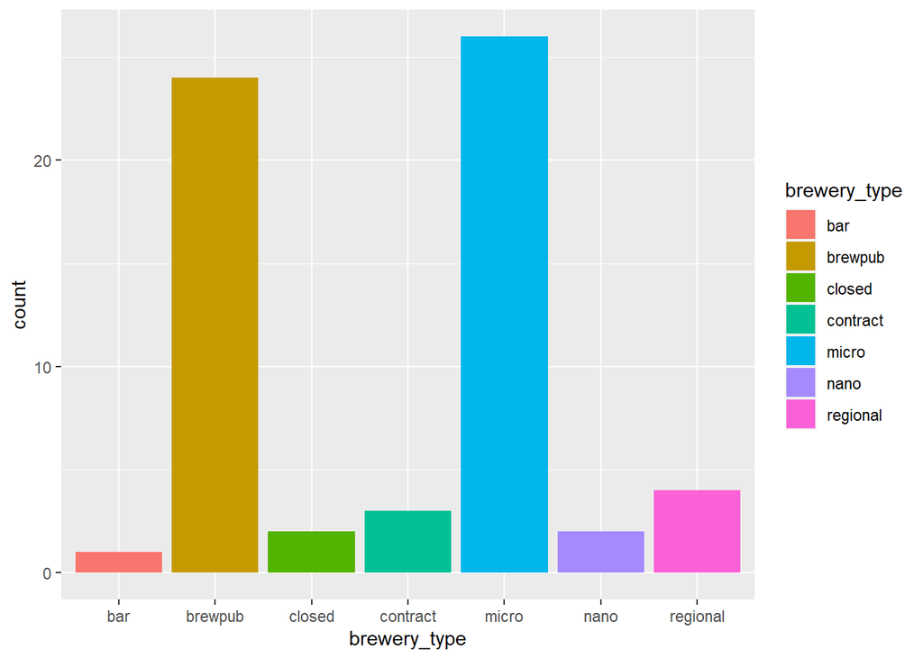

```r
ggplot(combined_tibble2, aes(x=brewery_type, fill=brewery_type)) + geom_bar()
```

### scatter plot

We use the scatter plot to understand the distribution between two numeric columns which we is our longitude and latitude columns. We investigate how do the longitude vary with latitude.

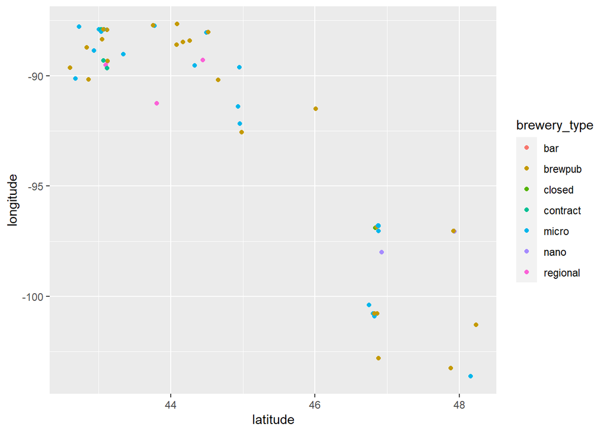

```r
ggplot(combined_tibble2, aes(y=longitude, x= latitude, col=brewery_type)) + geom_point()
```

### Box plot

In a box plot we try to investigate how a numerical value change with a categorical value. We choose latitude for the numerical value and brewery type for the categorical variable.

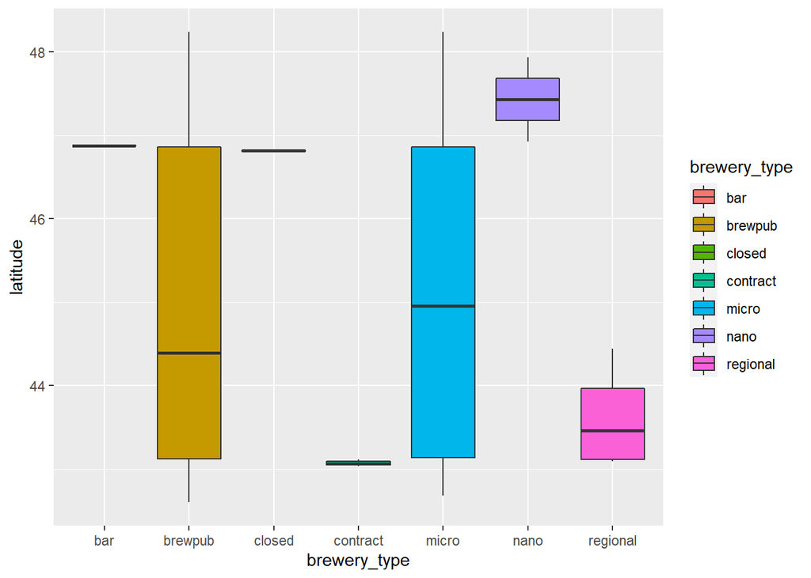

```r
ggplot(combined_tibble2, aes(x = brewery_type, y = latitude, fill=brewery_type )) + geom_boxplot()
```

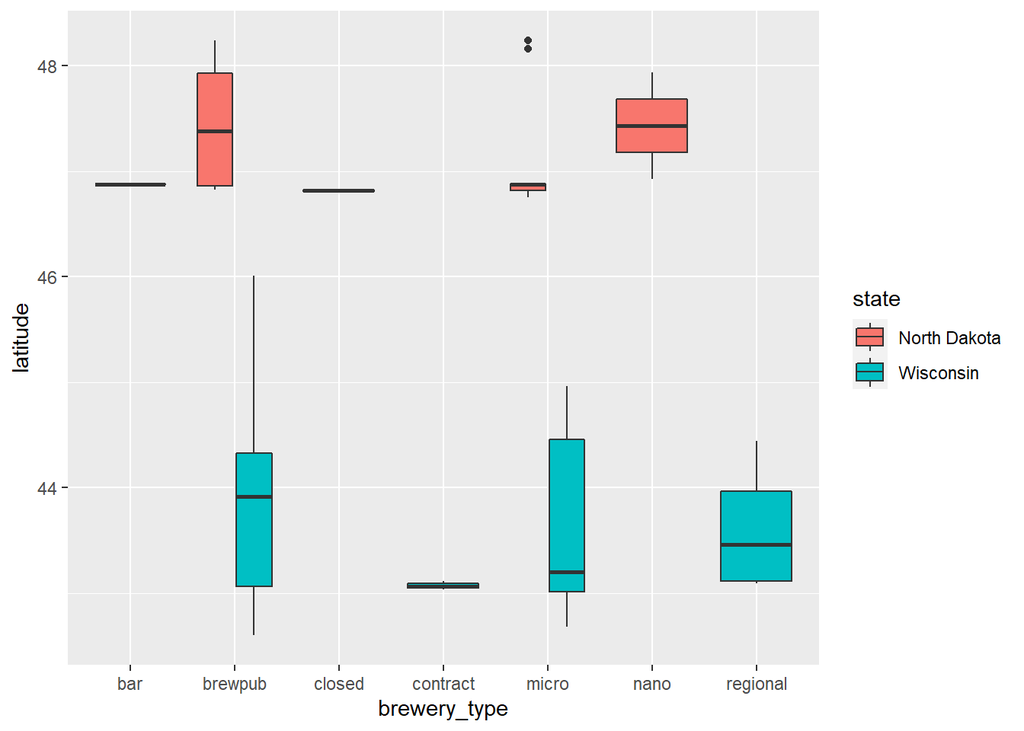

```r
ggplot(combined_tibble2, aes(x = brewery_type, y = latitude, fill=state )) + geom_boxplot()
```

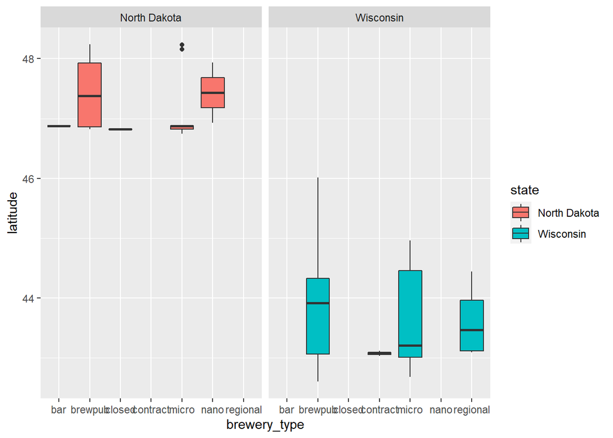

```r
ggplot(combined_tibble2, aes(x = brewery_type, y = latitude, fill=state )) + geom_boxplot() + facet_grid(~state)
```